# Aside

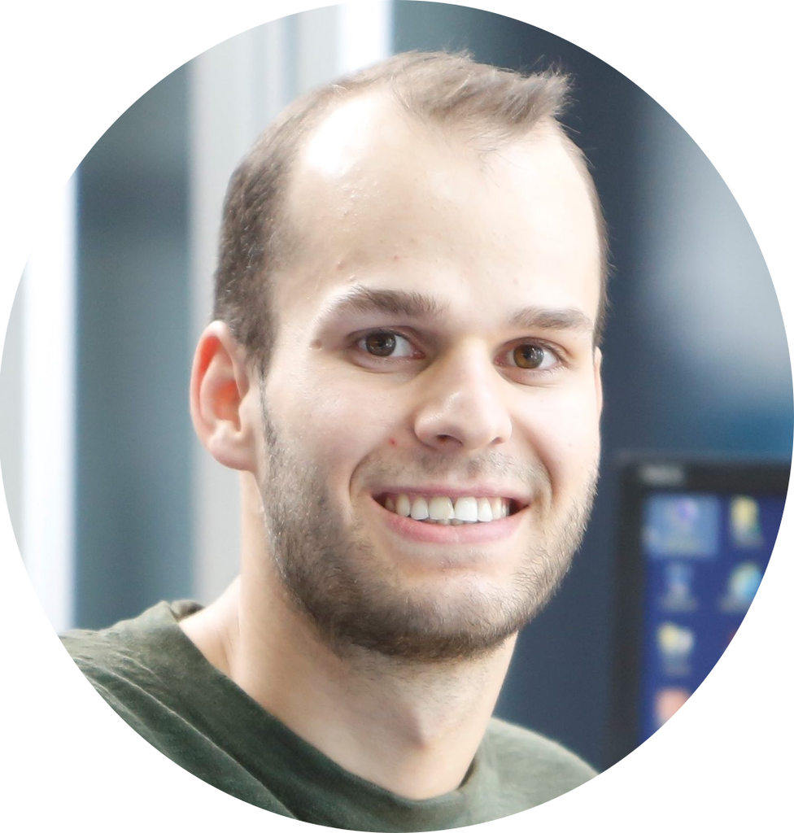

[Download a PDF of this CV](https://gregor-mathes.netlify.app/files/cv.pdf)

## Contact

- gregor.mathes@pim.uzh.ch
- [Twitter](https://twitter.com/GregorMathes)
- [Github](https://github.com/Ischi94)
- [My Website](https://gregor-mathes.netlify.app)
- [Linkedin](https://www.linkedin.com/in/gregor-mathes-2595311b6/)

## Language Skills

R

Markdown

Bash

C++

Python

SQL

Stan

## Disclaimer

Last updated on 2024-04-26.

# Main

## Gregor Mathes

Gregor Mathes is a PostDoc at the University of Zurich. His research interests include conservation palaeontology, analytical macroecology, and data science. He applies novel statistical tools to the fossil record to gain insights about Earths history. Using this information about the past, he focuses on the conservation of recent biodiversity under current climate change. A big ambition in Gregor Mathes work is the use and creation of free and open software.

## Education

### PostDoc

University of Zurich

Zurich

2023 - 2022

- PostDoc position on shark extinction risk together with Catalina Pimiento
- Additionally contributing to research projects of other team members

### PhD. Candidate, Analytical Palaeobiology

University of Bayreuth

Bayreuth

2022 - 2019

- Dissertation: The role of climate legacies in shaping extinction risk throughout Earth’s history
- Additionally contributing to various research projects of other team member covering sports ecology, macroecology, and geology. Providing help for programming, statistics, and data visualisation

### M.Sc., Analytical Palaeobiology and Earth System Research lab

Friedrich-Alexander University Erlangen-Nuremberg

Erlangen

2019 - 2018

- Thesis: The effect of palaeoclimate interactions on the extinction risk of organism
- Focus on statistics, programming, and academic skills

### B.Sc., Geoscience

Friedrich-Alexander University Erlangen-Nuremberg

Erlangen

2018 - 2013

- Thesis: Diagenesis of Halimeda
- Focus on palaeobiology, applied sedimentology, and geochemistry/ petrology

### Abitur

Hans-Sachs Gymnasium Nuremberg

Nuremberg

2013 - 2005

- Thesis: Die Alpen - Paradebeispiel plattentektonischer Prozesse
- Focus on German, Mathematics, English, History, and Physics

## Industry Experience

I am a member of the Conservation Paleobiology Network and currently chair of the training series sub-committee. I am a private lecturer at the Hanns-Seidel-Stiftung e.V. providing talks and classes on climate change and Earths system.

### Lecturer

Hanns-Seidel Stiftung

Kloster Banz

2022 - 2019

- Lecturer for one week workshops covering topics such as mass extinctions or climate change

### Data Warehouse Solution

Friedrich-Alexander University Erlangen-Nuremberg

Erlangen

2019 - 2018

- Created a data base for the thin section collection of the Faculty Palaeobiology
- Data base environment based on WissKI

## Teaching Experience

### Lecturer

Friedrich-Alexander University Erlangen-Nuremberg

Erlangen

Current - 2020

- Served as TA for foraminifera lecture in the microfossils course 2020 of the master program “Analytical Palaeobiology”

### Lecturer

University of Zurich

Zurich

2024 - 2023

- Served as TA for various courses and exercises on Paleontolog and Marine Megafauna

### Workshop leader

Macroecology

Bayreuth

2023 - 2023

- Led a workshop on Paleontology for macroecologist at the Ecography conference

### Lecturer

University of Bayreuth

Bayreuth

2022 - 2022

- Served as TA for analytical palaeobiology, providing both lectures and practice courses for graduate students from various departments in Bayreuth

### Lecturer

University of Bayreuth

Bayreuth

2021 - 2021

- Served as TA for analytical palaeobiology, providing both lectures and practice courses for graduate students from various departments in Bayreuth

### Lecturer

Friedrich-Alexander University Erlangen-Nuremberg

Erlangen

2019 - 2019

- Served as TA for foraminifera lecture in the microfossils course 2019 of the master program “Analytical Palaeobiology”

### Lecturer

Friedrich-Alexander University Erlangen-Nuremberg

Erlangen

2019 - 2017

- Invited talks on carbonate microfacies during the internationally renowned [Flügel-Course](https://www.gzn.nat.fau.eu/palaeontology/outreach/flugel-course/)
- Focus on foraminifera and thin sections

## Selected Awards and Honors

### Early career research award

Bayreuther Zentrum für Ökologie und Umweltforschung (BayCEER)

Bayreuth

2023

- For outstanding achievements during the dissertation

### Palaeo-Price

Commision of the Swiss Journal of Palaeontology

Mendrisio

2023

- Awarded for excellent contributions to the field of Palaeontology

### Nominated for the “Bayrische Kulturpreis” by the faculty for Geosciensces

University of Bayreuth

Bayreuth

2023

- Awarded as best Dissertation of the Faculty 2023

### Dissertation - Summa cum laude

University of Bayreuth

Bayreuth

2023

- Dissertation with highest honours

### Certification for teaching in higher education of the Bavarian universities

ProfiLehre Plus

Bayreuth

2022 - 2021

- Formal proof of teaching competencies and didactic and pedagogical qualifications in numerous application contexts, as certified by Bavarian universities based on international standards

### Cited in the IPCC’s sixth assessment report

Intergovernmental Panel on Climate Change

N/A

2022

- Citation for our paper on complex cascading effects in the climate system ([Mathes et al. 2021](https://doi.org/10.1038/s41559-020-01377-w)) in chapter 1 of the Working Group 2 SPM

### Best Talk Award - Third Prize

Bayreuther Zentrum für Ökologie und Umweltforschung (BayCEER)

Bayreuth

2020

- Young researcher award. Presentation title: Extinction risk controlled by climate interactions

### Best student talk

Conservation Paleobiology Symposium

Bologna

2020

- Presentation title: Extinction risk controlled by interaction of long-term and short-term climate change

### Master thesis with distinction

Friedrich-Alexander University Erlangen-Nuremberg

Erlangen

2019

- Awarded for master theses with an overall grade below 1.2

### Invited talk on carbonate microfacies

Friedrich-Alexander University Erlangen-Nuremberg

Erlangen

2019

- Invited talk at the international course on carbonate microfacies about foraminifera and their applications

### Winner of the 1st FAU International Science Slam

Friedrich-Alexander University Erlangen-Nuremberg

Erlangen

2018

- The Faculty of Sciences hosted FAU’s first International Science Slam. Presentation title: Warning: the following presentation may contain foraminifera

## Science outreach

Trying to make my reseach accessible and public, I am engaging in various open science efforts.

### Geologic field trips

Franconian Switzerland

Nuremberg

Current - 2016

- Organiser of educational and interdisciplinary excursions for school classes.

### Public talks

Various

N/A

Current - 2017

- Various talks about climate change given at schools and colleges

### Lange Nacht der Wissenschaften

Friedrich-Alexander University Erlangen-Nuremberg

Erlangen

2022 - 2019

- Organiser of a big science outreach event at the Geoscience faculty

### Online lectures

The Halifax Academy

West Yorkshire

2020

- Various online talks for school classes about the sixth mass extinction

### Erlanger Markttage

Friedrich-Alexander University Erlangen-Nuremberg

Erlangen

2019 - 2018

- Co-Organiser of a science outreach event in Erlangen

### Kinderuniversität

Friedrich-Alexander University Erlangen-Nuremberg

Nuremberg

2019

- Co-Organiser of a science outreach event for children in Nuremberg